# Documentação e Análise dos Resultados

# Introdução

Esta é a documentação oficial do projeto, com as linhas de código explicadas e comentadas, e os resultados que obtivemos com as previsões.

O objetivo deste projeto é realizar a previsão da eficiência de extintores elétricos usando Machine Learning em linguagem R.

Este projeto faz parte da Formação Cientista de Dados da Data Science Academy.

## Fontes de dados:

https://www.muratkoklu.com/datasets/vtdhnd07.php

Os detalhes do dataset estão disponíveis no README.

# Código explicado e comentado

Importando os pacotes necessários e lendo os dados do arquivo.

```r
library(readxl)
library(ggplot2)
library(randomForest)
library(caret)
library(e1071)
library(class)
library(gmodels)

dados = read_xlsx("Acoustic_Extinguisher_Fire_Dataset.xlsx", sheet = "A_E_Fire_Dataset")
```

Transformando os dados para a classe data.frame

```r
dados = as.data.frame(dados)
```

Vamos colocar um seed para reproduzir os mesmos exemplos nas execuções.

```r
set.seed(105)
```

Checando valores missing

```r
dim(dados)
```

```
## [1] 17442     7
```

```r
sum(is.na(dados$STATUS))
```

```
## [1] 0
```

Não temos valores missing, então não precisamos nos preocupar com isso.

Checando os tipos de dados

```r
str(dados)
```

```
## 'data.frame':    17442 obs. of  7 variables:
##  $ SIZE     : num  1 1 1 1 1 1 1 1 1 1 ...
##  $ FUEL     : chr  "gasoline" "gasoline" "gasoline" "gasoline" ...
##  $ DISTANCE : num  10 10 10 10 10 10 10 10 10 10 ...
##  $ DESIBEL  : num  96 96 96 96 109 109 103 95 102 93 ...
##  $ AIRFLOW  : num  0 0 2.6 3.2 4.5 7.8 9.7 12 13.3 15.4 ...
##  $ FREQUENCY: num  75 72 70 68 67 66 65 60 55 52 ...
##  $ STATUS   : num  0 1 1 1 1 1 1 1 1 1 ...
```

Transformando os tipos de dados

```r
dados$SIZE = as.factor(dados$SIZE)
dados$FUEL = as.numeric(as.factor(dados$FUEL))
dados$STATUS = as.factor(dados$STATUS)
```

Checando a fequência dos dados, para verificar se precisaremos usar alguma técnica para balancear os dados

```r
summary(dados)
```

```
##  SIZE          FUEL          DISTANCE      DESIBEL          AIRFLOW
##  1:3078   Min.   :1.000   Min.   : 10   Min.   : 72.00   Min.   : 0.000
##  2:3078   1st Qu.:1.000   1st Qu.: 50   1st Qu.: 90.00   1st Qu.: 3.200
##  3:3078   Median :2.000   Median :100   Median : 95.00   Median : 5.800
##  4:3078   Mean   :2.412   Mean   :100   Mean   : 96.38   Mean   : 6.976
##  5:3078   3rd Qu.:4.000   3rd Qu.:150   3rd Qu.:104.00   3rd Qu.:11.200
##  6:1026   Max.   :4.000   Max.   :190   Max.   :113.00   Max.   :17.000
##  7:1026
##    FREQUENCY     STATUS
##  Min.   : 1.00   0:8759
##  1st Qu.:14.00   1:8683
##  Median :27.50
##  Mean   :31.61
##  3rd Qu.:47.00
##  Max.   :75.00
##
```

```r
table(dados$DISTANCE)
```

```
##
##  10  20  30  40  50  60  70  80  90 100 110 120 130 140 150 160 170 180 190
## 918 918 918 918 918 918 918 918 918 918 918 918 918 918 918 918 918 918 918
```

```r
table(dados$DESIBEL)
```

```
##
##   72   74   75   76   78   79   80   82   83   84   85   86   87   88   89   90
##   17  119  136   51   85   51  119   34   85  119  238  442  425  561  782 1105
##   91   92   93   94   95   96   97   98   99  100  101  102  103  104  105  106
##  969 1462  765  646  765 1360  272   51   34  119  255  612  595  867 1071 1360
##  107  108  109  110  111  112  113
##  612  646  187  272  102   34   17
```

```r
table(dados$AIRFLOW)
```

```
##
##    0  0.4  0.8    1  1.1  1.3  1.4  1.5  1.6  1.7  1.9    2  2.1  2.2  2.3  2.5
## 1632   51   34   85   34   68  102  119  102   51  102  153  136  255  170  221
##  2.6  2.7  2.8  2.9    3  3.1  3.2  3.3  3.4  3.6  3.7  3.8  3.9    4  4.2  4.3
##  153  221  255  204   17  187  357  238  289  187  374  153  119  238  306  136
##  4.4  4.5  4.6  4.8  4.9    5  5.2  5.3  5.4  5.6  5.7  5.8    6  6.1  6.3  6.4
##  238  238  102  170  119  221  187  119   68  204  187  153  136   85   85   85
##  6.5  6.7  6.8    7  7.1  7.2  7.3  7.4  7.5  7.7  7.8  7.9  8.1  8.2  8.3  8.5
##  221   51   51  153   51   34   17  119  153  119  102  102   51   68   68  136
##  8.6  8.7  8.8  8.9    9  9.1  9.2  9.3  9.5  9.6  9.7  9.9   10 10.2 10.3 10.4
##   85   17  102   34   85   17   85  136  136   51  102   68  238  119  187  102
## 10.5 10.6 10.7 10.9   11 11.2 11.3 11.5 11.6 11.8 11.9   12 12.2 12.3 12.5 12.6
##   51  187  119  153  306  153  119  204  136   51  119  255  136  272  255  102
## 12.8 12.9   13 13.1 13.2 13.3 13.4 13.5 13.6 13.8 13.9   14 14.1 14.2 14.3 14.4
##   68  102   34   34  153  136   17  204   68  136   34   17   85  136   17  204
## 14.5 14.6 14.8 14.9   15 15.1 15.2 15.4 15.5 15.7   16 16.1 16.3 16.6   17
##  102   34   85  153   34   51  255  136  102   34  102   17   34   17   17
```

```r
table(dados$FREQUENCY)
```

```
##
##   1   2   3   4   5   6   7   8   9  10  11  12  13  14  15  16  17  18  19  20
## 323 323 323 323 323 323 323 323 323 323 323 323 323 323 323 323 323 323 323 323
##  21  22  23  24  25  26  27  28  30  32  33  34  35  36  38  40  42  44  45  46
## 323 323 323 323 323 323 323 323 323 323 323 323 323 323 323 323 323 323 323 323
##  47  48  50  51  52  55  60  65  66  67  68  70  72  75
## 323 323 323 323 323 323 323 323 323 323 323 323 323 323
```

```r
table(dados$STATUS)
```

```
##
##    0    1
## 8759 8683
```

```r
table(dados$FUEL)
```

```
##
##    1    2    3    4
## 5130 5130 2052 5130
```

Vamos vizualizar as variáveis numéricas com boxplot

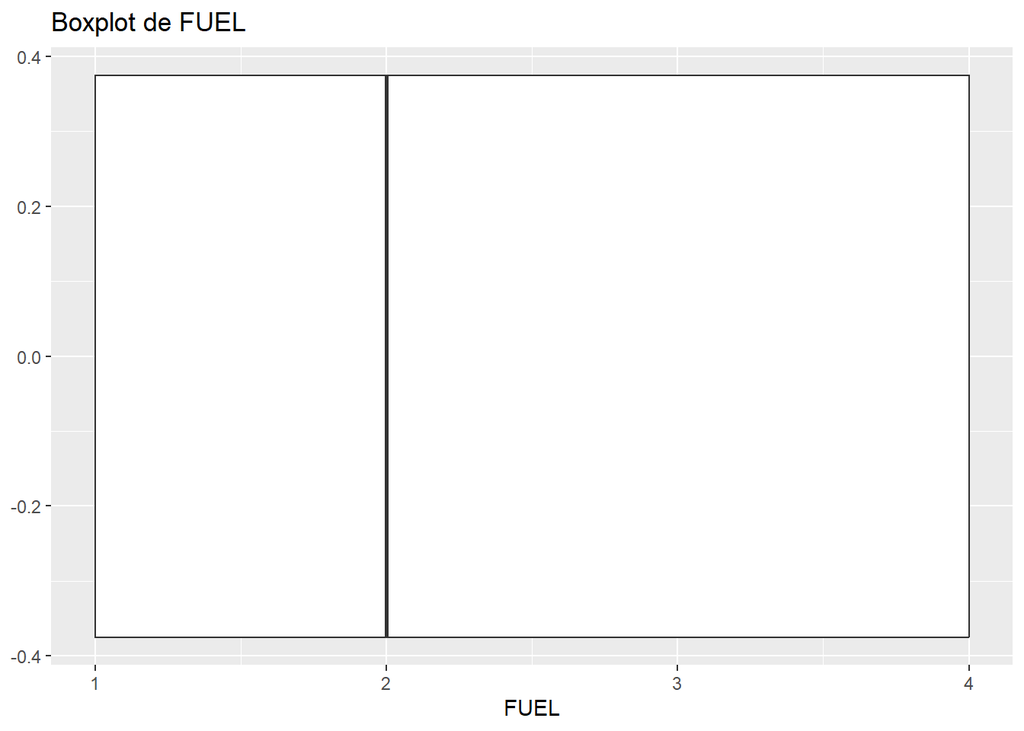

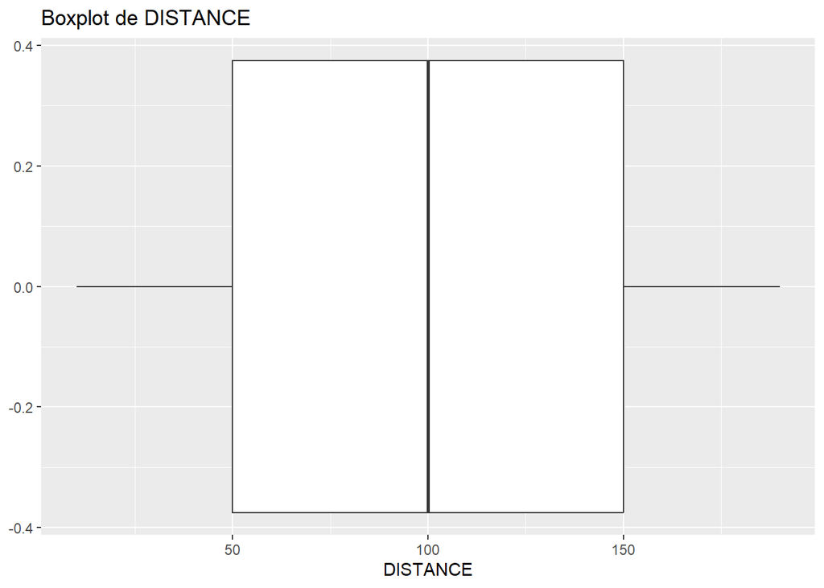

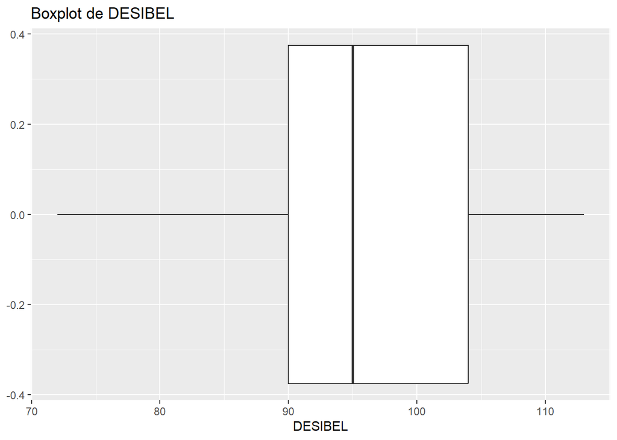

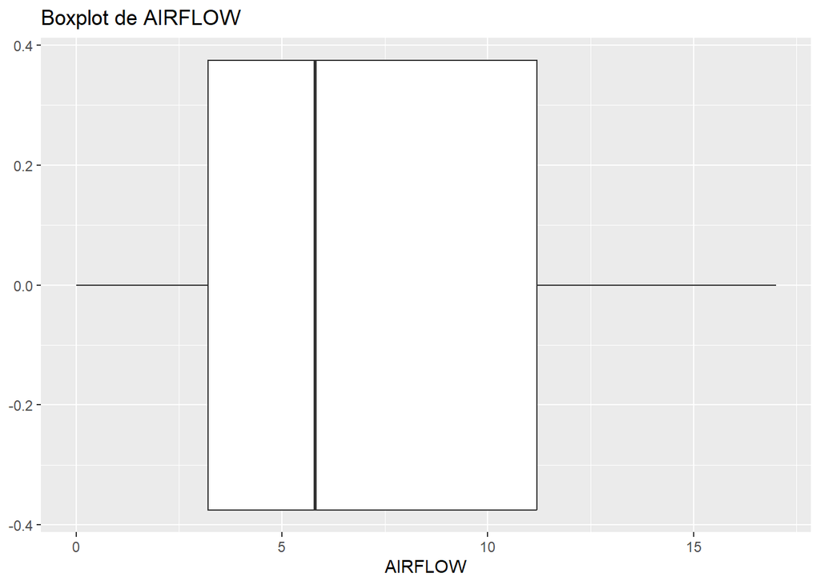

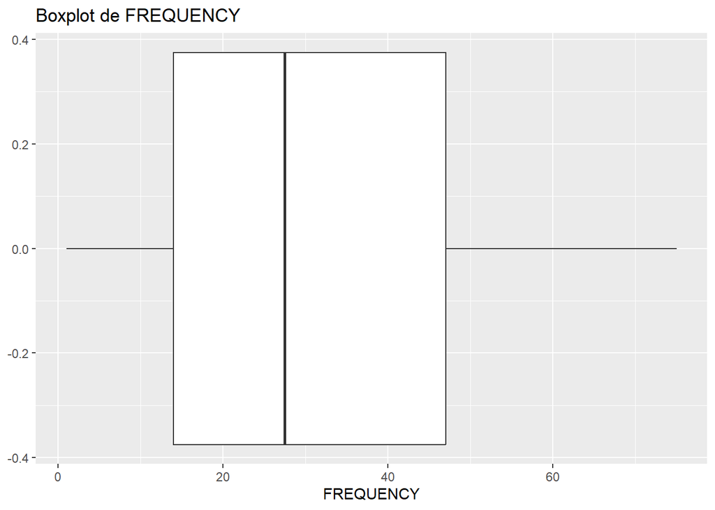

```r
col_names = names(dados)
lapply(col_names, function(x){
  if(!is.factor(dados[,x])) {
    ggplot(dados, aes_string(x)) +
      geom_boxplot() +
      ggtitle(paste("Boxplot de", x))}})
```

Criando gráfico de barras para as variáveis do tipo fator

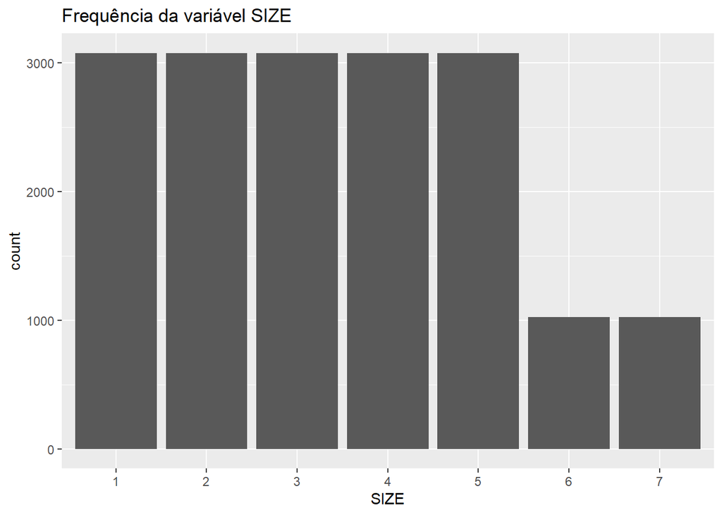

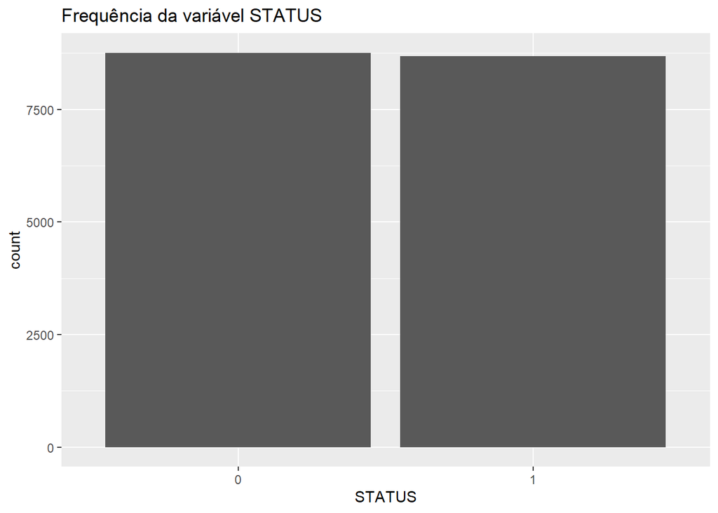

```r
lapply(col_names, function(x){
  if(is.factor(dados[,x])) {
    ggplot(dados, aes_string(x)) +
      geom_bar() +
      ggtitle(paste("Frequência da variável",x))}})
```

Criando os dados de treino e de teste com o pacote caret

```r
index = createDataPartition(dados$STATUS, p = .70, list = FALSE)
treino = dados[index, ]
teste = dados[-index, ]

dim(treino)
```

```
## [1] 12211     7
```

```r
dim(teste)
```

```
## [1] 5231    7
```

Criando o primeiro modelo com o knn

```r
treino_labels = dados[index, 7]
teste_labels = dados[-index, 7]

modelo_knn_v1 = knn(train = treino,
                    test = teste,
                    cl = treino_labels,
                    k = 7)

CrossTable(x = teste_labels, y = modelo_knn_v1, prop.chisq = FALSE)
```

```
##
##
##    Cell Contents
## |-------------------------|
## |                       N |
## |           N / Row Total |
## |           N / Col Total |
## |         N / Table Total |
## |-------------------------|
##
##
## Total Observations in Table:  5231
##
##
##              | modelo_knn_v1
## teste_labels |         0 |         1 | Row Total |
## -------------|-----------|-----------|-----------|
##            0 |      2486 |       141 |      2627 |
##              |     0.946 |     0.054 |     0.502 |
##              |     0.918 |     0.056 |           |
##              |     0.475 |     0.027 |           |
## -------------|-----------|-----------|-----------|
##            1 |       221 |      2383 |      2604 |
##              |     0.085 |     0.915 |     0.498 |
##              |     0.082 |     0.944 |           |
##              |     0.042 |     0.456 |           |
## -------------|-----------|-----------|-----------|
## Column Total |      2707 |      2524 |      5231 |
##              |     0.517 |     0.483 |           |
## -------------|-----------|-----------|-----------|
##
##
```

```r
confusionMatrix(modelo_knn_v1, reference = teste_labels)
```

```
## Confusion Matrix and Statistics
##
##           Reference
## Prediction    0    1
##          0 2486  221
##          1  141 2383
##
##                Accuracy : 0.9308
##                  95% CI : (0.9236, 0.9375)
##     No Information Rate : 0.5022
##     P-Value [Acc > NIR] : < 2.2e-16
##
##                   Kappa : 0.8616
##
##  Mcnemar's Test P-Value : 3.294e-05
##
##             Sensitivity : 0.9463
##             Specificity : 0.9151
##          Pos Pred Value : 0.9184
##          Neg Pred Value : 0.9441
##              Prevalence : 0.5022
##          Detection Rate : 0.4752
##    Detection Prevalence : 0.5175
##       Balanced Accuracy : 0.9307
##
##        'Positive' Class : 0
##
```

Precisão de 93%.

Vamos tentar criar outros modelos com o valor de k diferente.

```r
modelo_knn_v2 = knn(train = treino,
                    test = teste,
                    cl = treino_labels,
                    k = 5)

CrossTable(x = teste_labels, y = modelo_knn_v2, prop.chisq = FALSE)
```

```
##
##
##    Cell Contents
## |-------------------------|
## |                       N |
## |           N / Row Total |
## |           N / Col Total |
## |         N / Table Total |
## |-------------------------|
##
##
## Total Observations in Table:  5231
##
##
##              | modelo_knn_v2
## teste_labels |         0 |         1 | Row Total |
## -------------|-----------|-----------|-----------|
##            0 |      2497 |       130 |      2627 |
##              |     0.951 |     0.049 |     0.502 |
##              |     0.927 |     0.051 |           |
##              |     0.477 |     0.025 |           |
## -------------|-----------|-----------|-----------|
##            1 |       198 |      2406 |      2604 |
##              |     0.076 |     0.924 |     0.498 |
##              |     0.073 |     0.949 |           |
##              |     0.038 |     0.460 |           |
## -------------|-----------|-----------|-----------|
## Column Total |      2695 |      2536 |      5231 |
##              |     0.515 |     0.485 |           |
## -------------|-----------|-----------|-----------|
##
##
```

```r
confusionMatrix(modelo_knn_v2, reference = teste_labels)
```

```
## Confusion Matrix and Statistics
##
##           Reference
## Prediction    0    1
##          0 2497  198
##          1  130 2406
##
##                Accuracy : 0.9373
##                  95% CI : (0.9304, 0.9437)
##     No Information Rate : 0.5022
##     P-Value [Acc > NIR] : < 2.2e-16
##
##                   Kappa : 0.8746
##
##  Mcnemar's Test P-Value : 0.0002161
##
##             Sensitivity : 0.9505
##             Specificity : 0.9240
##          Pos Pred Value : 0.9265
##          Neg Pred Value : 0.9487
##              Prevalence : 0.5022
##          Detection Rate : 0.4773
##    Detection Prevalence : 0.5152
##       Balanced Accuracy : 0.9372
##
##        'Positive' Class : 0
##
```

A segunda versão do modelo possui a mesma acurácia do primeiro, 93%.

```r
modelo_knn_v3 = knn(train = treino,
                    test = teste,
                    cl = treino_labels,
                    k = 10)

CrossTable(x = teste_labels, y = modelo_knn_v3, prop.chisq = FALSE)
```

```
##
##
##    Cell Contents
## |-------------------------|
## |                       N |
## |           N / Row Total |
## |           N / Col Total |
## |         N / Table Total |
## |-------------------------|
##
##
## Total Observations in Table:  5231
##
##
##              | modelo_knn_v3
## teste_labels |         0 |         1 | Row Total |
## -------------|-----------|-----------|-----------|
##            0 |      2477 |       150 |      2627 |
##              |     0.943 |     0.057 |     0.502 |
##              |     0.916 |     0.059 |           |
##              |     0.474 |     0.029 |           |
## -------------|-----------|-----------|-----------|
##            1 |       228 |      2376 |      2604 |
##              |     0.088 |     0.912 |     0.498 |
##              |     0.084 |     0.941 |           |
##              |     0.044 |     0.454 |           |
## -------------|-----------|-----------|-----------|
## Column Total |      2705 |      2526 |      5231 |
##              |     0.517 |     0.483 |           |
## -------------|-----------|-----------|-----------|
##
##
```

```r
confusionMatrix(modelo_knn_v3, reference = teste_labels)
```

```
## Confusion Matrix and Statistics
##
##           Reference
## Prediction    0    1
##          0 2477  228
##          1  150 2376
##
##                Accuracy : 0.9277
##                  95% CI : (0.9204, 0.9346)
##     No Information Rate : 0.5022
##     P-Value [Acc > NIR] : < 2.2e-16
##
##                   Kappa : 0.8555
##
##  Mcnemar's Test P-Value : 7.481e-05
##
##             Sensitivity : 0.9429
##             Specificity : 0.9124
##          Pos Pred Value : 0.9157
##          Neg Pred Value : 0.9406
##              Prevalence : 0.5022
##          Detection Rate : 0.4735
##    Detection Prevalence : 0.5171
##       Balanced Accuracy : 0.9277
##
##        'Positive' Class : 0
##
```

Acurácia de 92%.

Vamos criar modelos com outros algoritmos. Primeiro vamos tentar o Support Vector Machine (SVM)

```r
modelo_svm_v1 <- svm(STATUS ~ .,
                     data = treino,
                     type = 'C-classification',
                     kernel = 'radial')

previsao_svm_v1 = predict(modelo_svm_v1, teste)

table(previsao_svm_v1, teste$STATUS)
```

```
##
## previsao_svm_v1    0    1
##               0 2489  165
##               1  138 2439
```

```r
mean(previsao_svm_v1 == teste$STATUS)
```

```
## [1] 0.9420761
```

Conseguimos uma acurácia de 94% com o algoritmo SVM

Vamos tentar também o algoritmo Random Forest.

```r
modelo_rf_v1 = randomForest(STATUS ~ .,
                            data = treino,
                            ntree = 100,
                            nodesize = 10)

previsao_rf_v1 = predict(modelo_rf_v1, teste)

table(previsao_rf_v1, teste$STATUS)
```

```
##
## previsao_rf_v1    0    1
##              0 2530  125
##              1   97 2479
```

```r
mean(previsao_rf_v1 == teste$STATUS)
```

```
## [1] 0.9575607
```

Conseguimos a melhor acurácia com o random forest, de 95%.

Vamos tentar mudar os hiperparâmetros do random forest para tentar conseguir um resultado melhor.

```r
modelo_rf_v2 = randomForest(STATUS ~ .,
                            data = treino,
                            ntree = 200,
                            nodesize = 10)

previsao_rf_v2 = predict(modelo_rf_v2, teste)

table(previsao_rf_v2, teste$STATUS)
```

```
##
## previsao_rf_v2    0    1
##              0 2530  126
##              1   97 2478
```

```r
mean(previsao_rf_v2 == teste$STATUS)
```

```
## [1] 0.9573695
```

Acurácia de 95%, levemente inferior ao primeiro modelo.

Vamos tentar mais uma modificação

```r
modelo_rf_v3 = randomForest(STATUS ~ .,
                            data = treino,
                            ntree = 200,
                            nodesize = 5)

previsao_rf_v3 = predict(modelo_rf_v3, teste)

table(previsao_rf_v3, teste$STATUS)
```

```
##
## previsao_rf_v3    0    1
##              0 2535  119
##              1   92 2485
```

```r
mean(previsao_rf_v3 == teste$STATUS)
```

```
## [1] 0.9596635
```

Acurácia de 95%, levemente superior.

Vamos tentar mais uma modificação.

```r
modelo_rf_v4 = randomForest(STATUS ~ .,
                            data = treino,
                            ntree = 200,
                            nodesize = 1)

previsao_rf_v4 = predict(modelo_rf_v4, teste)

table(previsao_rf_v4, teste$STATUS)
```

```
##
## previsao_rf_v4    0    1
##              0 2543  109
##              1   84 2495
```

```r
mean(previsao_rf_v4 == teste$STATUS)
```

```
## [1] 0.9631046
```

Acurácia de 96%, conseguimos a melhor performance com essa versão do modelo random forest.